# Stats 1 PISA assignment

Vernon Davies

2025-02-18

1. The findings of this report indicate that students having a room of their own or whether a student has access to a home computer on which to do homework are the most significant factors determining math PISA score 2022 for the country of Brazil. However the significance of the variables in affecting math ability is still quite weak (in comparison to other multiple regressions I have done in the past such as skills test 2 and previous report submission with the Indonesia data). It is believed the low adjusted r squared values are a result of the data being randomly simulated.
2. For this report the student 2022 Brazil data was used, initially a few variables were looked at such as does the student have their own desk (‘desk’)? Does the student’s home have a dishwasher (‘dishwasher’)? Does the student have access to the internet excluding via a smartphone (‘internet’)? Does the student have access to a computer for school work (‘computer’)? Does the student have a room of their own (‘room’)? Also looked at was father’s education level, mother’s education level and the gender of the student. Info on the variables looked at can be found in the student questionnaire which accompanied the exam. The response variable chosen was math ability. Math ability is important for students in life for logic, memory and problem solving. It is also important for access to well paid software and technology positions.
3. The findings of this report were based on our simulated Brazil data that was constructed to be similar to the original data.

The PISA student data from 2022 measures numeracy, literacy and science knowledge between the age of 15 years 3 months and 16 years 2 months, when the students are enrolled in formal education. The PISA 2022 involved schools from 81 different countries representing about 29 million 15/16 year olds. Information for this report (and on PISA) was gathered via the OECD.org website and the student questionnaire which accompanies the PISA exams. Education is one of the most important tools in lifting children out of poverty and into a better life across the world. A thorough and varied education can mean the difference between a person ending up with better life expectancy, ending up in a well paid job, providing a better environment for their own children. Educated citizens can mean the difference between a successful economy at a macroeconomic level and a failed state. By completing secondary school, students can access tertiary education which are centers of ideas and progressiveness across cities across the world. The student experience molds young people which can affect the rest of their lives. Friendships gained at tertiary education can last students for the rest of their lives. Tertiary education contributes to making a less ignorant and more well rounded person, one who is more able to question their prejudices which can lead to a better society for all. Movements such as LGBT (lesbian gay bisexual trans) have been advanced greatly by student protests in universities across the world. By measuring the performance of education, society can help educators improve their methods. Competition of schools and education systems can be healthy in the right regulatory environment. Of course the PISA tests are not the be and end all, critical thinking and the ability to discuss and debate are skills not measured in these tests. The PISA tests are still a work in progress like most things. This report looks specifically at the country of Brazil, a middle income country. It was thought that this country would have more of a variation in students with access internet, room, computer etc as opposed to the United Kingdom. This report looks at how gender, internet access at home (excluding smartphone use), the student having a room of their own, the student having access to a computer that they can use for schoolwork, the father’s education level, the mother’s education level. For father’s and mother’s education level, ISCED, means ‘international standard classification of education.’ There are 4 levels in the data: ‘less than 1’ ‘1’ ‘2’ and ‘3.’ For further investigation I would look at other countries math ability data around the world, maybe one more developed country and one undeveloped country. Other columns could also be looked at such as ‘wealth’ ‘book’ (books owned), whether the student has access to a car at home. Other response variables such as ‘science’ and ‘read’ could also be looked at.

First we will load the PISA student 2022 student data.

| year | country | school_id | student_id | mother_educ | father_educ | gender | computer | internet | math | read | science | stu_wgt | desk | room | dishwasher | television | computer_n | car | book | wealth | escs |
| --- | --- | --- | --- | --- | --- | --- | --- | --- | --- | --- | --- | --- | --- | --- | --- | --- | --- | --- | --- | --- | --- |
| 2022 | ALB | 800282 | 800001 | ISCED 1 | ISCED 2 | female | yes | NA | 179.583 | 247.571 | 335.468 | 3.15874 | NA | NA | NA | NA | NA | NA | 101-200 | NA | 1.1112 |
| 2022 | ALB | 800115 | 800002 | ISCED 1 | ISCED 2 | male | no | no | 308.247 | 258.472 | 315.021 | 4.34524 | NA | no | NA | 1 | 0 | 0 | 11-25 | NA | -3.0507 |
| 2022 | ALB | 800242 | 800003 | ISCED 3A | ISCED 2 | male | yes | yes | 267.514 | 284.670 | 358.675 | 7.83860 | NA | yes | NA | 1 | 1 | 1 | 101-200 | NA | -0.1867 |
| 2022 | ALB | 800245 | 800005 | ISCED 1 | ISCED 1 | female | yes | yes | 272.649 | 321.547 | 214.823 | 8.49148 | NA | yes | NA | 1 | 1 | 0 | 11-25 | NA | -3.2198 |
| 2022 | ALB | 800285 | 800006 | ISCED 3A | ISCED 2 | female | yes | yes | 435.473 | 464.366 | 434.997 | 3.70957 | NA | yes | NA | 1 | 1 | 2 | 11-25 | NA | -1.0548 |
| 2022 | ALB | 800172 | 800007 | ISCED 3A | ISCED 3A | male | yes | yes | 534.112 | 451.263 | 479.075 | 4.25946 | NA | no | NA | NA | 1 | 1 | more than 500 | NA | 1.0855 |

Next we will select the country of Brazil’s data. Brazil is a middle income country. The PISA country abbreviation (‘BRA’) was found via Googling and the result makes sense intuitively (BRA for Brazil).

Ok, so firstly we will look at the data, to get an idea of the variables involved, what research question we are going to look at, the response variable we are interested in etc.

| year | country | school_id | student_id | mother_educ | father_educ | gender | computer | internet | math | read | science | stu_wgt | desk | room | dishwasher | television | computer_n | car | book | wealth | escs |
| --- | --- | --- | --- | --- | --- | --- | --- | --- | --- | --- | --- | --- | --- | --- | --- | --- | --- | --- | --- | --- | --- |
| 2022 | BRA | 7600608 | 7600001 | ISCED 3A | ISCED 3A | male | no | yes | 310.794 | 383.785 | 287.183 | 210.6558 | NA | yes | NA | 1 | 0 | 0 | 11-25 | NA | -0.2957 |
| 2022 | BRA | 7600247 | 7600002 | ISCED 3A | ISCED 3A | female | no | yes | 493.038 | 435.650 | 566.271 | 197.9116 | NA | yes | NA | 1 | 0 | 2 | 26-100 | NA | -0.7738 |
| 2022 | BRA | 7600332 | 7600003 | ISCED 3A | ISCED 3A | female | yes | yes | 363.687 | 415.172 | 494.208 | 233.5087 | NA | yes | NA | 1 | 0 | 1 | 26-100 | NA | 0.5204 |
| 2022 | BRA | 7600339 | 7600005 | NA | ISCED 3A | female | yes | yes | 239.214 | 314.012 | 328.532 | 188.6934 | NA | yes | NA | NA | NA | 2 | 0-10 | NA | -0.0799 |
| 2022 | BRA | 7600157 | 7600007 | ISCED 1 | ISCED 2 | female | no | yes | 398.384 | 310.588 | 353.695 | 244.6246 | NA | yes | NA | 1 | 0 | 0 | 11-25 | NA | -0.7457 |
| 2022 | BRA | 7600337 | 7600009 | NA | ISCED 1 | female | no | no | 354.606 | 449.564 | 408.992 | 239.6760 | NA | yes | NA | 1 | 0 | 0 | 11-25 | NA | -2.7935 |

For this report we will look at math ability, math ability is important for logic and memory and for access to tertiary education for students.

The second step is to look at cleaning the data:

```
[1] 10798
```

We can clearly see the number is NA values for the ‘desk’ column is huge. So we won’t bother with this variable going forward. Next we will look at NA values for ‘gender.’

```
[1] 0
```

We can clearly see the number of NA values are very few, so we will use ‘gender’ going forward. Now we will look at computer access (for homework) at the student’s home.

```
[1] 707
```

There are some NA values but overall we can use this variable. Now we will look at internet access (excluding internet by smartphone) in the home of the student.

```
[1] 682
```

We can clearly see the number of NA values are very few, so we will use ‘internet’ going forward. Now we will look at whether the student has a room of their own.

```
[1] 549
```

We can clearly see there are few NA values, so we will use ‘room’ going forward. Now we will look at whether the student’s home has a dishwasher. For a measure of the student’s home socioeconomic status.

```
[1] 10798
```

We can clearly see there are huge numbers of NA values in this column so we will not use this variable.

Next we will look at father’s education level. From Google ISCED means ‘international standard classification of education.’ From Google Gemini, ISCED 1 means primary school education, ISCED 2 means middle school education (we don’t have middle school in Scotland), ISCED 3 means secondary education.

```
[1] 1117
```

We can clearly see there are few NA values, we will use ‘father_educ’ going forward.

Now we will look at mother’s education level.

```
[1] 702
```

So there is few NA values, and we will use this variable.

Finally we will check the ‘math’ response variable for NA values.

```
[1] 0
```

We can clearly see there are no NA values in the ‘math’ column.

Now we will omit all rows with NA values from the Father’s education column

| year | country | school_id | student_id | mother_educ | father_educ | gender | computer | internet | math | read | science | stu_wgt | desk | room | dishwasher | television | computer_n | car | book | wealth | escs |
| --- | --- | --- | --- | --- | --- | --- | --- | --- | --- | --- | --- | --- | --- | --- | --- | --- | --- | --- | --- | --- | --- |
| 2022 | BRA | 7600608 | 7600001 | ISCED 3A | ISCED 3A | male | no | yes | 310.794 | 383.785 | 287.183 | 210.6558 | NA | yes | NA | 1 | 0 | 0 | 11-25 | NA | -0.2957 |
| 2022 | BRA | 7600247 | 7600002 | ISCED 3A | ISCED 3A | female | no | yes | 493.038 | 435.650 | 566.271 | 197.9116 | NA | yes | NA | 1 | 0 | 2 | 26-100 | NA | -0.7738 |
| 2022 | BRA | 7600332 | 7600003 | ISCED 3A | ISCED 3A | female | yes | yes | 363.687 | 415.172 | 494.208 | 233.5087 | NA | yes | NA | 1 | 0 | 1 | 26-100 | NA | 0.5204 |
| 2022 | BRA | 7600339 | 7600005 | NA | ISCED 3A | female | yes | yes | 239.214 | 314.012 | 328.532 | 188.6934 | NA | yes | NA | NA | NA | 2 | 0-10 | NA | -0.0799 |
| 2022 | BRA | 7600157 | 7600007 | ISCED 1 | ISCED 2 | female | no | yes | 398.384 | 310.588 | 353.695 | 244.6246 | NA | yes | NA | 1 | 0 | 0 | 11-25 | NA | -0.7457 |
| 2022 | BRA | 7600337 | 7600009 | NA | ISCED 1 | female | no | no | 354.606 | 449.564 | 408.992 | 239.6760 | NA | yes | NA | 1 | 0 | 0 | 11-25 | NA | -2.7935 |

Now we will reorder the factor levels for Father’s Education so they make more sense (putting ‘less than ISCED 1’ at the beginning rather than at the end)

Now We will plot father’s education level against math ability of the student (son/daughter of the father)

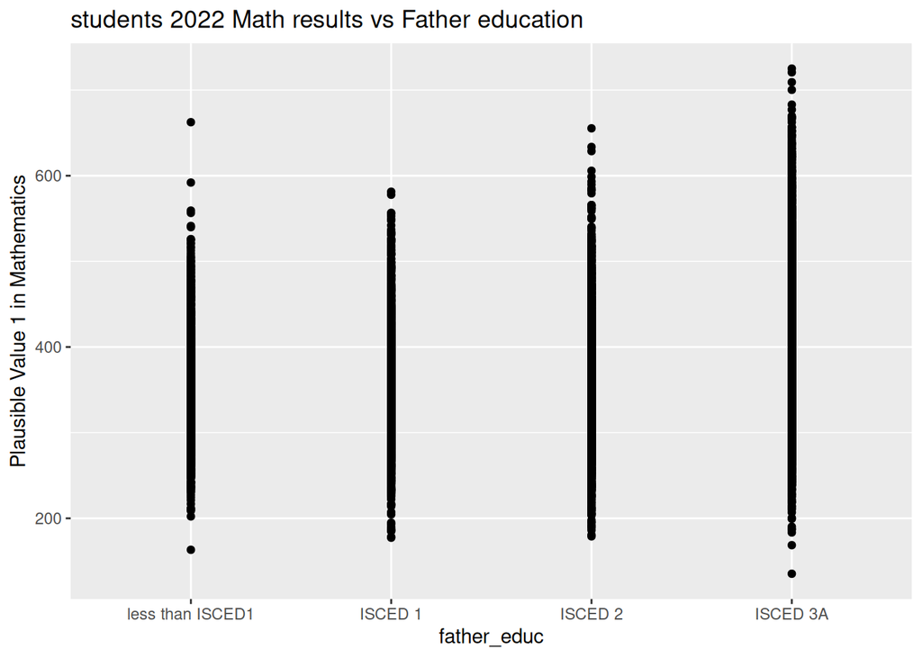

Now we will omit the NA values from mother’s education column.

Now We will reorder the factor levels for mother’s education as we did for father’s education.

Now we will plot mother’s education against math ability of the student.

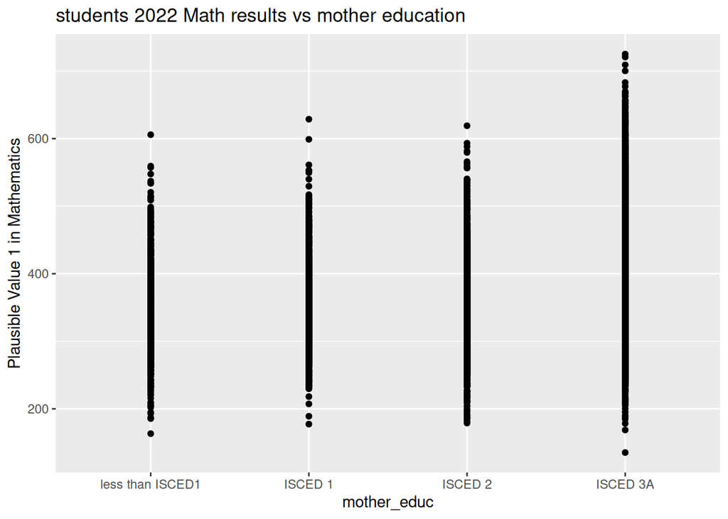

Now we will clean the ‘computer,’ ‘internet’ and ‘room’ columns of NA values.

Now we will check our progress, and look at the data set again.

| year | country | school_id | student_id | mother_educ | father_educ | gender | computer | internet | math | read | science | stu_wgt | desk | room | dishwasher | television | computer_n | car | book | wealth | escs |
| --- | --- | --- | --- | --- | --- | --- | --- | --- | --- | --- | --- | --- | --- | --- | --- | --- | --- | --- | --- | --- | --- |
| 2022 | BRA | 7600608 | 7600001 | ISCED 3A | ISCED 3A | male | no | yes | 310.794 | 383.785 | 287.183 | 210.6558 | NA | yes | NA | 1 | 0 | 0 | 11-25 | NA | -0.2957 |
| 2022 | BRA | 7600247 | 7600002 | ISCED 3A | ISCED 3A | female | no | yes | 493.038 | 435.650 | 566.271 | 197.9116 | NA | yes | NA | 1 | 0 | 2 | 26-100 | NA | -0.7738 |
| 2022 | BRA | 7600332 | 7600003 | ISCED 3A | ISCED 3A | female | yes | yes | 363.687 | 415.172 | 494.208 | 233.5087 | NA | yes | NA | 1 | 0 | 1 | 26-100 | NA | 0.5204 |
| 2022 | BRA | 7600157 | 7600007 | ISCED 1 | ISCED 2 | female | no | yes | 398.384 | 310.588 | 353.695 | 244.6246 | NA | yes | NA | 1 | 0 | 0 | 11-25 | NA | -0.7457 |
| 2022 | BRA | 7600028 | 7600010 | ISCED 3A | ISCED 3A | female | no | yes | 390.784 | 447.242 | 419.256 | 248.6597 | NA | yes | NA | 1 | 0 | 0 | 11-25 | NA | -1.2113 |
| 2022 | BRA | 7600296 | 7600012 | ISCED 3A | ISCED 3A | female | yes | yes | 345.997 | 270.034 | 365.466 | 118.0579 | NA | yes | NA | 1 | 1 | 1 | 0-10 | NA | 0.1223 |

Now we will plot the distribution of math scores:

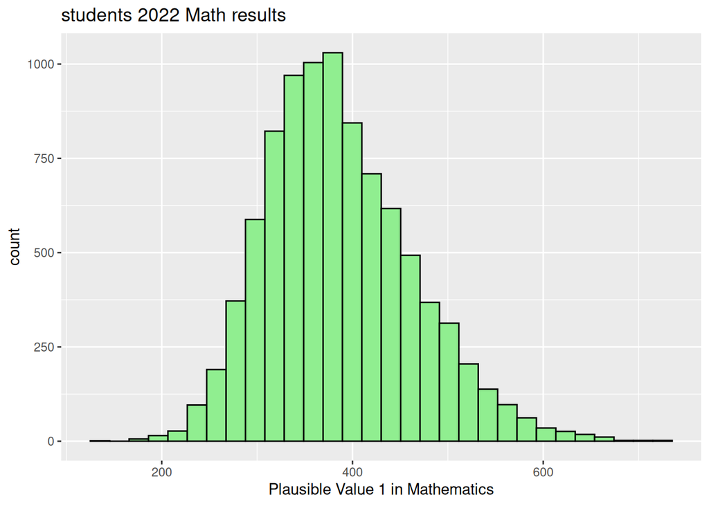

Now we will look at a summary of the maths scores to check if there is a max value, we need to know this for our simulation later.

```
   Min. 1st Qu.  Median    Mean 3rd Qu.    Max.
  135.3   331.7   377.5   386.3   433.7   725.1
```

So we can see the max value is 725.1 so the max value for the maths test doesn’t seem to have been reached (no student got full marks)

Now we will select the columns we want to use for further analysis.

First we will plot the student’s home computer access against math ability of the student.

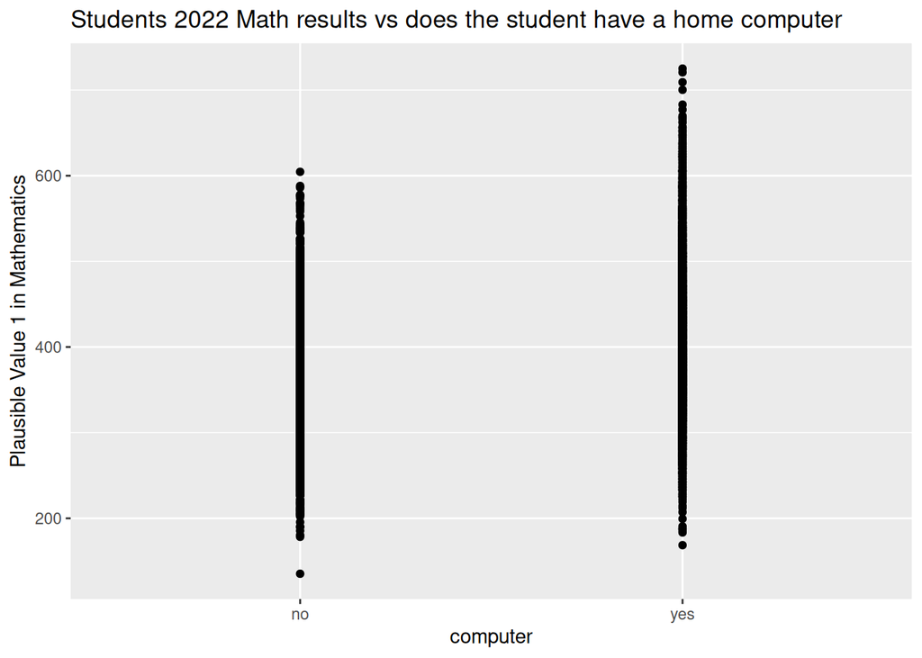

Now we will plot internet access (excluding internet via smartphone) against math ability of the student.

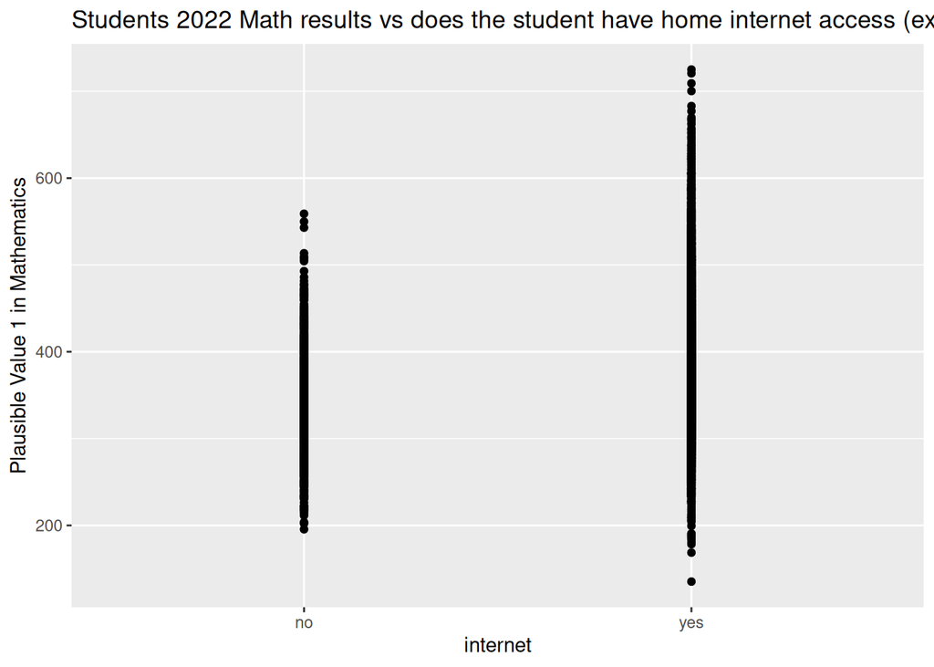

Now we will plot whether the student has a room of their own versus math ability.

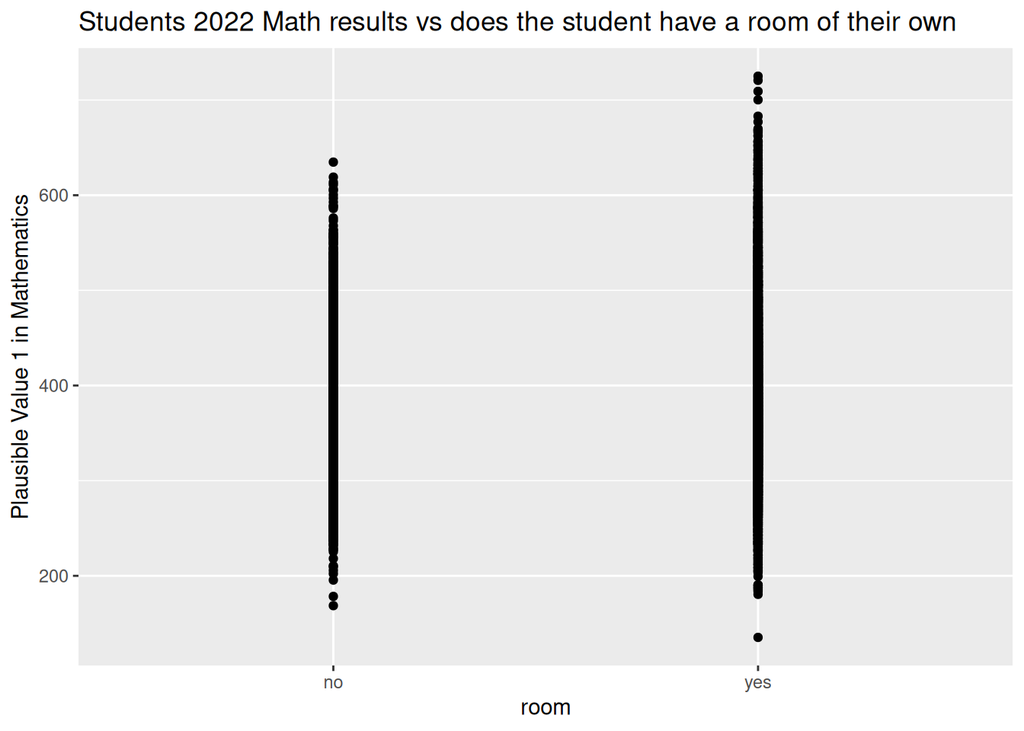

Now we will check if the math score distribution is normal or not by using a QQ plot.

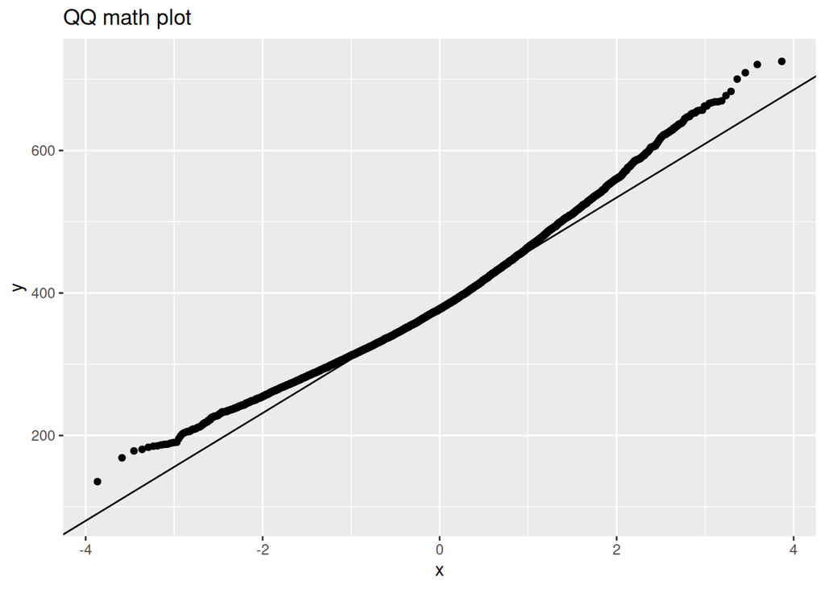

Since the QQ plot is a reasonable enough straight line we will now look at the mean and standard deviation of the math score data.

```
[1] 386.3493
```

```
[1] 76.99218
```

Now we will simulate a fresh set of data for our analysis.

Now we will look at a summary of the math score data.

```
   Min. 1st Qu.  Median    Mean 3rd Qu.    Max.
  154.1   333.8   385.8   386.9   442.0   658.7
```

Now we will take a look at our simulated data.

| math | gender | internet | room | computer | father_educ | mother_educ |
| --- | --- | --- | --- | --- | --- | --- |
| 387.4435 | female | 0 | 1 | 0 | 4 | 4 |
| 371.8126 | female | 1 | 0 | 1 | 3 | 1 |
| 280.4075 | female | 0 | 1 | 0 | 1 | 1 |
| 339.8641 | female | 0 | 0 | 1 | 1 | 4 |
| 408.6800 | female | 1 | 1 | 0 | 3 | 4 |
| 416.0142 | female | 0 | 1 | 1 | 2 | 1 |

Now we will look at the data type for each column.

```
tibble [1,000 × 7] (S3: tbl_df/tbl/data.frame)
 $ math       : num [1:1000] 387 372 280 340 409 ...
 $ gender     : chr [1:1000] "female" "female" "female" "female" ...
 $ internet   : num [1:1000] 0 1 0 0 1 0 0 0 0 1 ...
 $ room       : num [1:1000] 1 0 1 0 1 1 1 1 0 0 ...
 $ computer   : num [1:1000] 0 1 0 1 0 1 1 1 1 1 ...
 $ father_educ: num [1:1000] 4 3 1 1 3 2 3 1 4 4 ...
 $ mother_educ: num [1:1000] 4 1 1 4 4 1 4 2 3 1 ...
```

Now we will turn the gender column into a factor. This is for use later with our multiple regression.

Now to check the data type again to check we have successfully changed the ‘gender’ column into a factor.

```
tibble [1,000 × 7] (S3: tbl_df/tbl/data.frame)
 $ math       : num [1:1000] 387 372 280 340 409 ...
 $ gender     : Factor w/ 2 levels "female","male": 1 1 1 1 1 1 2 1 2 1 ...
 $ internet   : num [1:1000] 0 1 0 0 1 0 0 0 0 1 ...
 $ room       : num [1:1000] 1 0 1 0 1 1 1 1 0 0 ...
 $ computer   : num [1:1000] 0 1 0 1 0 1 1 1 1 1 ...
 $ father_educ: num [1:1000] 4 3 1 1 3 2 3 1 4 4 ...
 $ mother_educ: num [1:1000] 4 1 1 4 4 1 4 2 3 1 ...
```

Now we can see clearly our ‘gender’ column is a factor, with ‘male’ at the 2nd level and ‘female’ at the first level.

Now we will select the boys data from the simulation.

Now we will plot the boy’s math scores.

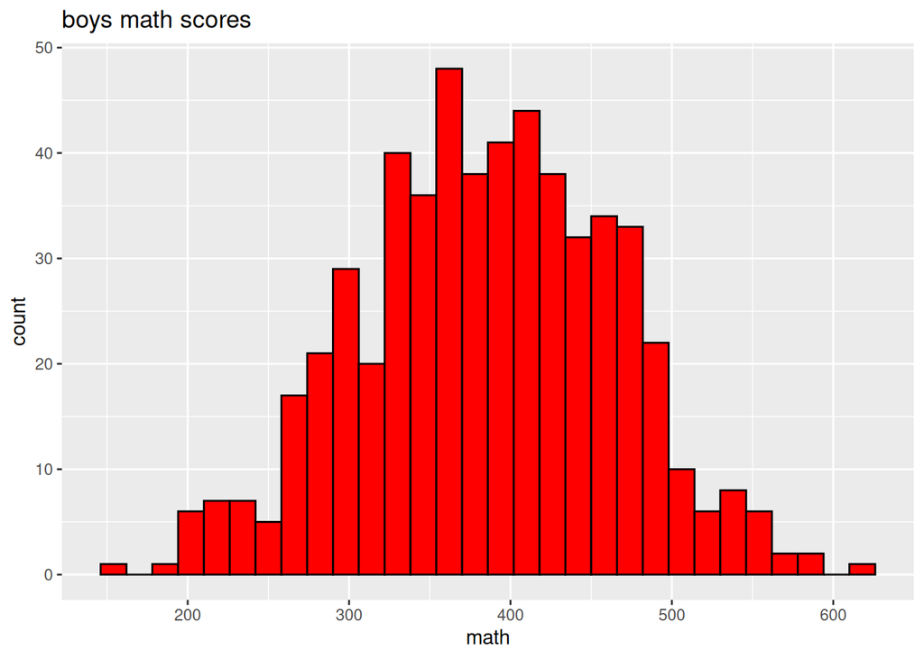

Now we will plot the girl’s math scores.

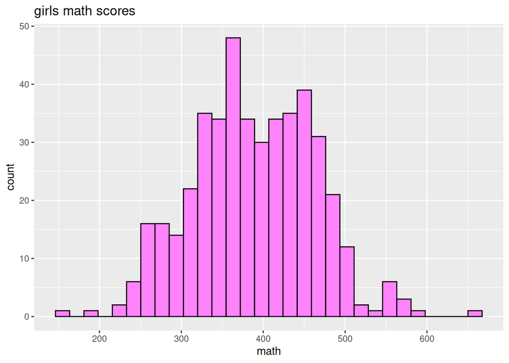

This is the average score for boys.

```
[1] 385.7897
```

This is the average score for girls.

```
[1] 388.2305
```

**Research Question: how does gender, a room of the student’s own, internet access, access to a home computer, father’s and mother’s education affect math scores in the PISA 2022 student data?**

First we have round 1 of the backward elimination multiple regression.

```
# A tibble: 7 × 2
  call                                                             adj.r.squared
  <chr>                                                                    <dbl>
1 math ~ gender + room + computer + father_educ + mother_educ           -0.00109
2 math ~ room + internet + computer + father_educ + mother_educ         -0.00118
3 math ~ gender + room + internet + computer + father_educ              -0.00153
4 math ~ gender + room + internet + computer + mother_educ              -0.00165
5 math ~ gender + room + internet + computer + father_educ + moth…      -0.00191
6 math ~ gender + internet + computer + father_educ + mother_educ       -0.00198
7 math ~ gender + room + internet + father_educ + mother_educ           -0.00201
```

Round 2, now we will remove ‘internet’ as this gives the highest adjusted r squared value.

```
# A tibble: 12 × 2
   call                                                            adj.r.squared
   <chr>                                                                   <dbl>
 1 math ~ room + computer + father_educ + mother_educ                  -0.000364
 2 math ~ gender + room + computer + father_educ                       -0.000689
 3 math ~ gender + room + computer + mother_educ                       -0.000813
 4 math ~ gender + room + computer + father_educ + mother_educ         -0.00109
 5 math ~ room + internet + computer + father_educ + mother_educ       -0.00118
 6 math ~ gender + computer + father_educ + mother_educ                -0.00120
 7 math ~ gender + room + father_educ + mother_educ                    -0.00125
 8 math ~ gender + room + internet + computer + father_educ            -0.00153
 9 math ~ gender + room + internet + computer + mother_educ            -0.00165
10 math ~ gender + room + internet + computer + father_educ + mot…     -0.00191
11 math ~ gender + internet + computer + father_educ + mother_educ     -0.00198
12 math ~ gender + room + internet + father_educ + mother_educ         -0.00201
```

Round 3 multiple regression. Now we will remove ‘gender’ as this gives the highest adjusted r squared value.

```
# A tibble: 16 × 2
   call                                                            adj.r.squared
   <chr>                                                                   <dbl>
 1 math ~ room + computer + father_educ                                0.0000499
 2 math ~ room + computer + mother_educ                               -0.0000825
 3 math ~ room + computer + father_educ + mother_educ                 -0.000364
 4 math ~ computer + father_educ + mother_educ                        -0.000419
 5 math ~ room + father_educ + mother_educ                            -0.000590
 6 math ~ gender + room + computer + father_educ                      -0.000689
 7 math ~ gender + room + computer + mother_educ                      -0.000813
 8 math ~ gender + room + computer + father_educ + mother_educ        -0.00109
 9 math ~ room + internet + computer + father_educ + mother_educ      -0.00118
10 math ~ gender + computer + father_educ + mother_educ               -0.00120
11 math ~ gender + room + father_educ + mother_educ                   -0.00125
12 math ~ gender + room + internet + computer + father_educ           -0.00153
13 math ~ gender + room + internet + computer + mother_educ           -0.00165
14 math ~ gender + room + internet + computer + father_educ + mot…    -0.00191
15 math ~ gender + internet + computer + father_educ + mother_educ    -0.00198
16 math ~ gender + room + internet + father_educ + mother_educ        -0.00201
```

Round 4 multiple regression, now we will remove ‘mother_educ’

```
# A tibble: 19 × 2
   call                                                            adj.r.squared
   <chr>                                                                   <dbl>
 1 math ~ room + computer                                             0.000285
 2 math ~ room + computer + father_educ                               0.0000499
 3 math ~ computer + father_educ                                      0.00000625
 4 math ~ room + computer + mother_educ                              -0.0000825
 5 math ~ room + father_educ                                         -0.000156
 6 math ~ room + computer + father_educ + mother_educ                -0.000364
 7 math ~ computer + father_educ + mother_educ                       -0.000419
 8 math ~ room + father_educ + mother_educ                           -0.000590
 9 math ~ gender + room + computer + father_educ                     -0.000689
10 math ~ gender + room + computer + mother_educ                     -0.000813
11 math ~ gender + room + computer + father_educ + mother_educ       -0.00109
12 math ~ room + internet + computer + father_educ + mother_educ     -0.00118
13 math ~ gender + computer + father_educ + mother_educ              -0.00120
14 math ~ gender + room + father_educ + mother_educ                  -0.00125
15 math ~ gender + room + internet + computer + father_educ          -0.00153
16 math ~ gender + room + internet + computer + mother_educ          -0.00165
17 math ~ gender + room + internet + computer + father_educ + mot…   -0.00191
18 math ~ gender + internet + computer + father_educ + mother_educ   -0.00198
19 math ~ gender + room + internet + father_educ + mother_educ       -0.00201
```

Round 5 now we will remove ‘father_educ.’

```
# A tibble: 21 × 2
   call                                               adj.r.squared
   <chr>                                                      <dbl>
 1 math ~ room + computer                                0.000285
 2 math ~ computer                                       0.000161
 3 math ~ room                                           0.000105
 4 math ~ room + computer + father_educ                  0.0000499
 5 math ~ computer + father_educ                         0.00000625
 6 math ~ room + computer + mother_educ                 -0.0000825
 7 math ~ room + father_educ                            -0.000156
 8 math ~ room + computer + father_educ + mother_educ   -0.000364
 9 math ~ computer + father_educ + mother_educ          -0.000419
10 math ~ room + father_educ + mother_educ              -0.000590
# ℹ 11 more rows
```

Since the adjusted r squared isn’t getting any bigger in this round we know we have reached its peak value. The optimum configuration, found via backward elimination, is ‘computer’ plus ‘room.’ That is whether a student has a room of their own and whether a student has access to a home computer in which to to homework on.

Here is the link to the PISA student questionnaire that accompanies the exam.

https://www.oecd.org/content/dam/oecd/en/data/datasets/pisa/pisa-2022-datasets/questionnaires/COMPUTER-BASED%20STUDENT%20questionnaire%20PISA%202022.pdf

Here is a word count for this document:

```
             file lines words bytes chars nonws path
1 PISA_report.Rmd   259  1797 10671 10671  8692    .
```